# The Infer Package and Bayes Factors

Jon Minton

# Introduction

This document will introduce a couple of concepts, and one R package, for performing statistical inference tests in R.

1. The There-is-only-one-test framework, and the R package infer
2. Bayes Factors, as distinct from Neyman-Pearson Hypothesis Testing frameoworks

# Proposed structure

- TIOOT/Infer
  - There-is-only-one-test : background
    - Allen Downey - a computer scientist’s take on statistical inference
      - 2011 - [There is only one test](http://allendowney.blogspot.com/2011/05/there-is-only-one-test.html)
      - 2016 - [There is still only one test](http://allendowney.blogspot.com/2016/06/there-is-still-only-one-test.html)

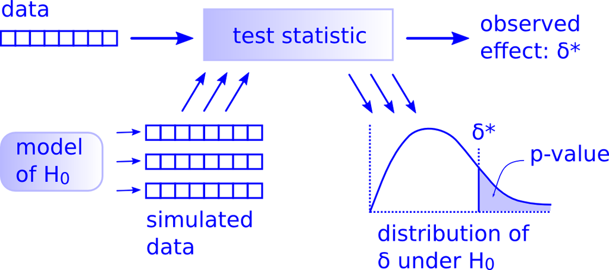

    - Null & Alternative Hypothesis
      - Null $H_0$: The (boring) world in which the proposed relationship between predictor and response variables is *false*
      - Alternative $H_A$: The (interesting) world in which the proposed relationship between predictor and response is *true*
    - P-values
      - > P-values are a measure of conflict between data and a hypothesis, and are certainly not direct expressions of a probability of hypotheses.
        - [Communicating Uncertainty about facts, numbers, and science](https://royalsocietypublishing.org/doi/pdf/10.1098/rsos.181870)
      - P-values are usually *indirect* strategies for investigating support for $H_A$, through quantifying *magnitude* and *direction* of conflict between data and $H_0$
        - *Direction of conflict*: One-tailed cf two-tailed tests
        - *Magnitude of conflict*: Probability of observing values of effect $\delta^{*}$ as or more extreme under $H_0$.
      - Neyman-Pearson Approach
        - Also prespecify $\alpha$: The magnitude of conflict between data and Null hypothesis, in expected direction, required to ‘reject the Null’
        - Typical $\alpha$ values: 0.05, 0.01
          - CERN: ‘Five Sigma’ (almost zero)
        - [The Sizeless Stare](https://www.amazon.co.uk/Cult-Statistical-Significance-Economics-Cognition/dp/0472050079)
      - Permutation approaches
        - A generic, computationally intensive, approach to producing a distribution of expected effect sizes under the Null
        - Key intuition:
          - $H_A$ says $X$ predicts/causes $Y$
          - Put another way: Values of $X$ are *informative* as to values of $Y$
          - Say $X$ is categorical, and can either be $A$ or $B$
          - The data $D$ is a series of values of $Y$, with *labels* attached: the corresponding values of $X$
          - Another way of expressing $H_A$ and $H_0$:
            - $H_A$: These labels *matter* (Are informative of $Y$)
            - $H_0$: These labels *don’t matter* (Are not informative of $Y$)
          - A corollary of $H_0$: If the labels don’t matter, there’s no harm (information lost) by reallocating them to $Y$ values at random
          - Random reallocation: Permutation
          - Repeat many times to estimate the Null distribution
  - [Infer package](https://github.com/tidymodels/infer)

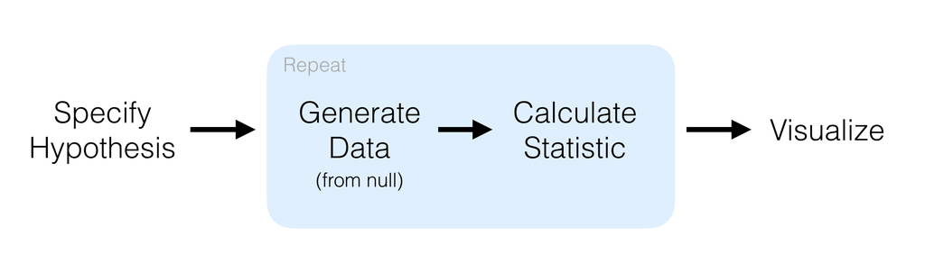

    - Verbs
      - `specify`
      - `hypothesize`
      - `generate`
      - `calculate`
  - DataCamp courses [(Learner beware)](https://www.buzzfeednews.com/article/daveyalba/datacamp-sexual-harassment-metoo-tech-startup)
    - [Foundations of Inference](https://www.datacamp.com/courses/foundations-of-inference)
    - [Inference for Linear Regression](https://www.datacamp.com/courses/inference-for-linear-regression)
    - [Inference for Numeric Data](https://www.datacamp.com/courses/inference-for-numerical-data)
    - [Inference for Categorical Data](https://www.datacamp.com/courses/inference-for-categorical-data)
  - [Avoiding Datacamp](https://bookdown.org/cteplovs/ismaykim/ismaykim.pdf)